# DATASCI 385 - Experimental Methods

Lecture 13 - Introduction to Quarto and DeclareDesign

Danilo Freire

danilo.freire@emory.edu

Department of Data and Decision Sciences  
Emory University

# Hello, everyone! 😊

# Brief recap 📚

## Last class, we discussed…

- The historical development of research ethics (Nuremberg Code, Tuskegee Study, Belmont Report)
- Core ethical principles: respect for persons, beneficence, and justice
- Informed consent requirements and procedures
- Considerations for anonymity and confidentiality in research data
- How Institutional Review Boards (IRBs) protect human subjects
- Ethical controversies in recent studies like Facebook’s emotional contagion study
- Adaptive research designs that maximise benefits and minimise harm
- Ethical responsibilities toward research staff and communities
- How ethical research practices improve data quality and research outcomes
- The principle of equipoise in determining when experiments are justified
- The need for special protections for vulnerable populations
- How ethical practices help prevent attrition and strengthen research validity

# Today’s plan 📅

## Introduction to Quarto and DeclareDesign

### Two useful tools for experimental research (and beyond)

- [Quarto](https://quarto.org/) is a great tool to write and publish reproducible documents
- It fits well with R Markdown and Jupyter Notebooks, so there is very little learning curve for you!
- Quarto also meets all the requirements for a good research workflow and literate programming
  - It is text-based, so you can use version control (e.g., Git)
  - It supports code execution and visualisation
  - It allows you to write in Markdown, LaTeX, and other formats

[figure not shown]

https://quarto.org/

## Introduction to Quarto and DeclareDesign

### Two useful tools for experimental research (and beyond)

- [DeclareDesign](https://declaredesign.org/) is a package for R that helps you design and analyse experiments
- We have already used it before, but today we will see more of its capabilities
- As we will see, DeclareDesign is a powerful tool to plan and execute experiments
  - It helps you define your research question and hypotheses
  - It guides you in choosing the right design and sample size
  - It provides tools to analyse your data and draw conclusions
- And it is simulation-based, so you can test your design before running the experiment
- I hope you can use it in your pre-analysis plans! 😉

[figure not shown]

https://declaredesign.org/

# Quarto 📝

## What is Quarto?

- Quarto (`.qmd`) is a document format that combines the best features of R Markdown and Jupyter Notebooks
- It is designed for reproducibility and literate programming, as mentioned before
- Literate programming is a programming paradigm that combines code and documentation in a single document
  - This makes your code more readable and easier to maintain
  - It also helps you communicate your results more effectively
- If you use R Markdown or Jupyter Notebooks, you already do literate programming!
- Why is literate programming important for experimental research?
  - It helps you keep track of your code and results
  - It makes it easier to share your work with others
  - It allows you to reproduce your analysis and results

## Why Quarto?

### Can’t I just use R Markdown or Jupyter Notebooks instead?

- Yes, you can!
- But Quarto has some advantages over R Markdown and Jupyter Notebooks
- For example, Quarto supports multiple programming languages (not just R and Python)
- It also has built-in support for interactive visualisations and data tables
- And it is designed to work well with version control systems like Git
- You can also use it to [publish your documents online](https://quarto.org/docs/publishing/) (like this one!), create [slideshows](https://quarto.org/docs/slides/), [websites](https://quarto.org/docs/websites/), and [books](https://quarto.org/docs/books/)
- Learn it once, use it everywhere! 🤓

## How to get started with Quarto?

- First, you need to [install Quarto](https://quarto.org/docs/get-started/)
- It is available for Windows, Mac, and Linux
- If you use [Homebrew](https://brew.sh/), you can install Quarto with `brew install quarto`
- In case you use [VS Code](https://code.visualstudio.com/), you can install the [Quarto extension](https://marketplace.visualstudio.com/items?itemName=quarto.quarto-vscode) too, which will save you a lot of time
- You can also use [Quarto in RStudio](https://quarto.org/docs/rstudio/)
- As [Quarto was created by the same people who made RStudio](https://posit.co/blog/announcing-quarto-a-new-scientific-and-technical-publishing-system/), it is very easy to use it in RStudio
  - Just install the [Quarto R package](https://quarto.org/docs/r-package/) and you are good to go!
  - `install.packages("quarto")`

[figure not shown]

Click on the image to visit [the Quarto installation page](https://quarto.org/docs/get-started/)

# Writing a Quarto document 📝

## How to write a Quarto document?

- Quarto documents are directly influenced by R Markdown
- All documents have three main components:
  - YAML header with metadata
  - Markdown content (text)
  - Code chunks (R, Python, Julia, etc.)
- [YAML](https://yaml.org/) stands for “YAML Ain’t Markup Language”
  - It is a human-readable data serialisation format
  - It is often used for configuration files and metadata
  - In Quarto, the YAML header contains information about the document (title, author, date, etc.)

```markdown
---
title: My Quarto Document
subtitle: A simple example
author: Danilo Freire
date: 2025-03-03
format: html
editor:
  render-on-save: true
---
```

## Markdown

- Headings: `#`, `##`, `###`, etc.
- Emphasis: `*italic*` or `_italics_`, `**boldface**` or `__boldface__`, `~~strikethrough~~`
- Lists: `*`, `1.`, `-`
- Links: `[text](url)`
- Images: `![alt text](url)`
- Code: `code`
- Tables:

```markdown
| Header 1 | Header 2 |
|----------|----------|
| Cell 1   | Cell 2   |
```

### Heading

*Italics*, **boldface**, and `code`.

List:

- Item 1
- Item 2
  - Subitem 1

This is a [link](https://www.emory.edu).

| Header 1 | Header 2 |
| --- | --- |
| Cell 1 | Cell 2 |

## Markdown

- Blockquotes: `> quote`
- Horizontal rules: `---`
- Footnotes: `[^1]`
- Superscript: `2^10^`
- Subscript: `H~2~O`
- Math: `$\LaTeX$`
- For equations, use `$` or `$$`
- Check the [LaTeX Wiki](https://en.wikibooks.org/wiki/LaTeX/Mathematics) for math symbols
- More at [Markdown Guide](https://www.markdownguide.org/)

> This is a blockquote.

This is a paragraph<sup>1</sup>.

Equation: $\mu = \frac{1}{n} \sum_{i=1}^{n} x_i$

2<sup>10</sup> is 1024, and H<sub>2</sub>O is water.

This is a horizontal rule.

[^1]: This is a footnote.

# Quarto engines

## knitr

````r
---
title: "ggplot2 demo"
  format:
    html:
      code-fold: true
---

## Meet Quarto

Quarto enables you to weave together content and executable code into a finished document. To learn more about Quarto see <https://quarto.org>.

```{r}
#| label: plot-penguins
#| echo: false
#| message: false
#| warning: false

library(tidyverse)
library(palmerpenguins)

ggplot(penguins,
       aes(x = flipper_length_mm, y = bill_length_mm)) +
geom_point(aes(color = species, shape = species)) +
scale_color_manual(values = c("darkorange","purple","cyan4")) +
  labs(
    title = "Flipper and bill length",
    subtitle = "Dimensions for penguins at Palmer Station LTER",
    x = "Flipper length (mm)", y = "Bill length (mm)",
    color = "Penguin species", shape = "Penguin species"
  ) +
theme_minimal()
````

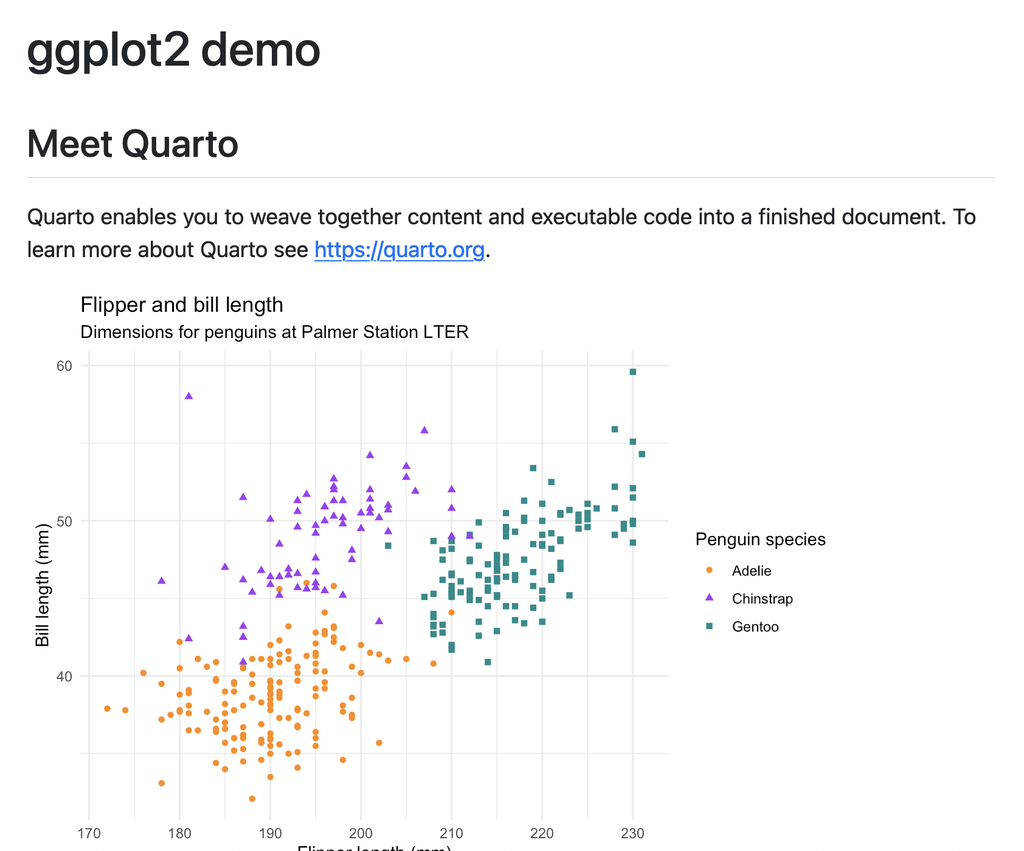

## Jupyter

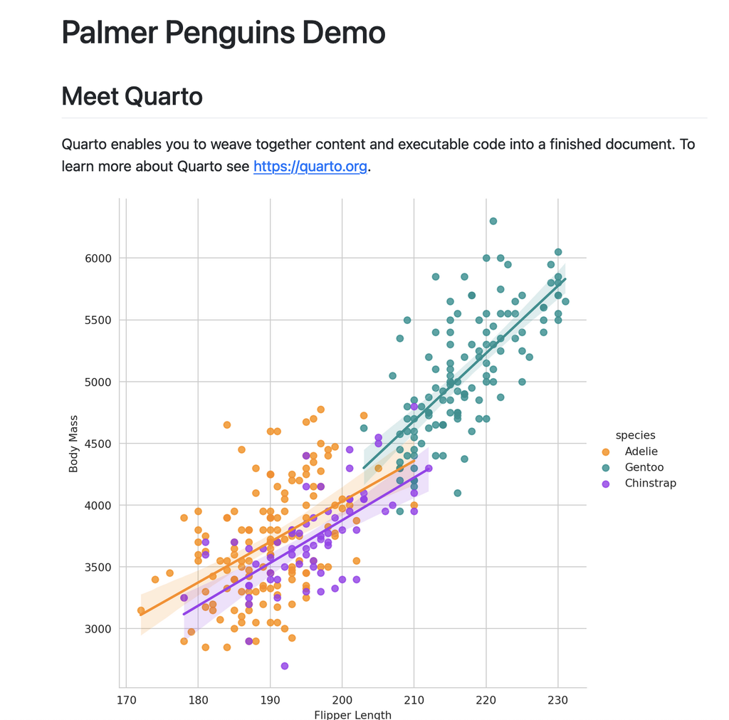

````
---
title: "Palmer Penguins Demo"
  format:
    html:
      code-fold: true
jupyter: python3
---


## Meet Quarto

Quarto enables you to weave together content and executable code into a finished document. To learn more about Quarto see <https://quarto.org>.

```{python}
#| echo: false
#| message: false

import pandas as pd
import seaborn as sns
from palmerpenguins import load_penguins
sns.set_style('whitegrid')

penguins = load_penguins()

g = sns.lmplot(x="flipper_length_mm",
               y="body_mass_g",
               hue="species",
               height=7,
               data=penguins,
               palette=['#FF8C00','#159090','#A034F0']);
g.set_xlabels('Flipper Length');
g.set_ylabels('Body Mass');
````

## PDFs

- Most articles and reports are in PDF format
- You will need a [LaTeX distribution](https://www.latex-project.org/get) to create PDFs
- You can install it with `quarto`:
  - `quarto install tinytex`
- If you use `R`, you can use [`tinytex`](https://yihui.org/tinytex/) with:
  - `install.packages("tinytex")`
  - `tinytex::install_tinytex()`
- This is strongly recommended as a LaTeX distribution is huge and takes a long time to install
- More information [here](https://quarto.org/docs/output-formats/pdf-basics.html)

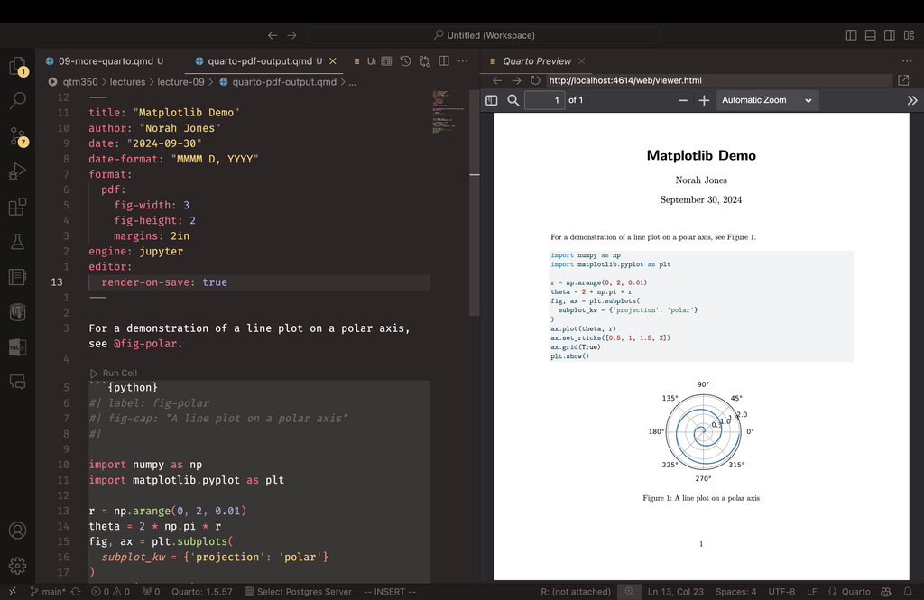

## Adding references

- You can add academic references to your documents using `BibTeX`
- `BibTeX` is a reference management software developed for LaTeX
- A `BibTeX` file is a plain text file with `.bib` extension
- You can add references to your YAML header
- Use `@key` to cite a reference, `[@key]` to cite in parentheses
- The key is the first line of the reference in the `.bib` file (e.g., `@article{nash1950equilibrium,...}`). The key here is `nash1950equilibrium`
- More information [here](https://quarto.org/docs/authoring/references.html)
- The easiest way to manage references is with a reference manager like [Zotero](https://www.zotero.org/) or download a BibTeX reference from Google Scholar
- Just search for a paper and click on the `cite` button
- Then click on `BibTeX` and copy the reference to your `.bib` file

## Example

[figure not shown]

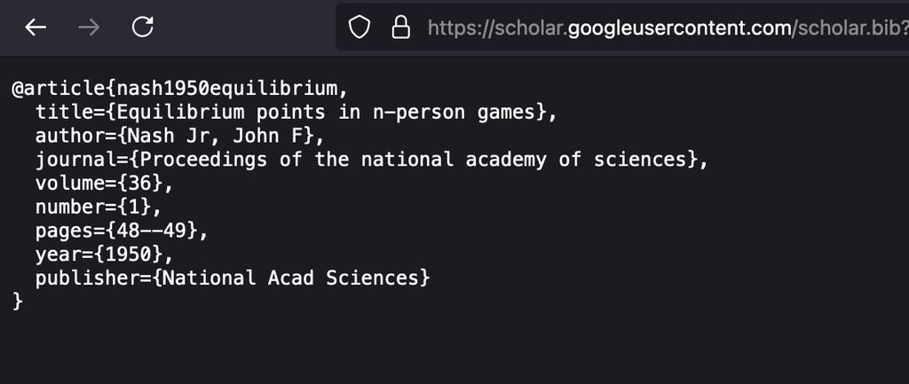

```
@article{nash1950equilibrium,
  title={Equilibrium points in n-person games},
  author={Nash Jr, John F},
  journal={Proceedings of the national academy of sciences},
  volume={36},
  number={1},
  pages={48--49},
  year={1950},
  publisher={National Acad Sciences}
}
```

- Save it on your `references.bib` file (or any other name, as long as you reference it in your YAML header and the file ends with `.bib`)
- Quarto will automatically format the references
- More information about BibTeX [here](https://www.overleaf.com/learn/latex/Bibliography_management_with_bibtex)

## Example

Then you add the references to your YAML header:

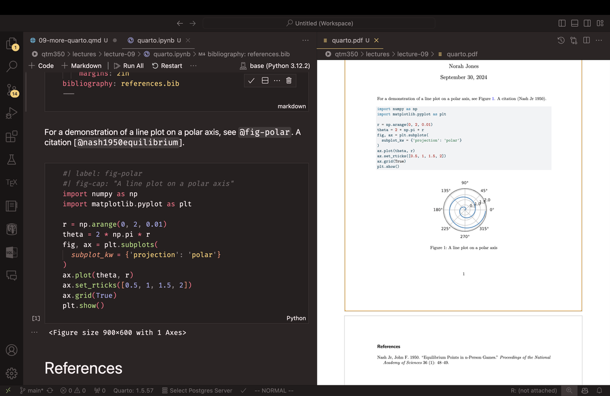

```markdown
---
title: "Matplotlib Demo"
author: "Norah Jones"
date: "2024-09-30"
date-format: "MMMM D, YYYY"
format:
  pdf:
    fig-width: 3
    fig-height: 2
    margins: 2in
bibliography: references.bib
---
```

# DeclareDesign 📊

## What is DeclareDesign?

### A package for designing and analysing data

- [DeclareDesign](https://declaredesign.org/) is an `R` package that helps you design and analyse experiments, quasi-experiments, and other observational studies
- Its main goal is to provide tools for declaration, diagnosis, and redesign in code, that is, to help you plan and execute your research before data analysis
- DeclareDesign can be thought of in 2 parts
  - The data fabrication step (this is the bulk of the code)
  - The evaluation step, where users can change initial assumptions and see how well their design actually worked (this is the computationally intensive part of the code)
- The great thing about DeclareDesign is that you can simulate any kind of design you can think of (e.g., experiments, regression discontinuity, difference-in-differences, even qualitative research!)
- However, most studies are not that complex, so you will rarely need to use all of DeclareDesign’s capabilities
- The authors have written a [book](https://declaredesign.org/library/) that explains the package in detail
- And they have also created a companion package, [DesignLibrary](https://declaredesign.org/r/designlibrary/), with pre-built designs that you can use right away! 🤓

## Six components of a DeclareDesign study

- Population: Set of units about which inferences are sought and their characteristics
  - Where should the theory apply? Who are the units of interest?
- Potential outcomes: Outcomes each unit might exhibit depending on how causal process changes the world
  - Rooted in theory; non-compliance, spillovers and attrition affect potential outcomes
- Sampling strategy: Strategy used to select units to include in study
  - How are we selecting units to analyse?
- Assignment: Manner in which units are assigned to reveal one potential outcome or another
  - Randomisation strategy used
- Estimand: Quantities that we want to learn about in the world, in terms of potential outcomes
  - What are we trying to estimate? ATE? Difference in means? Other quantities?
- Estimator: Procedure for generating estimates of the quantities we want to learn about
  - This is your statistical model (e.g., OLS, IV, etc.)

## DeclareDesign in action

- First, you need to install DeclareDesign with `install.packages("DeclareDesign")` and DesignLibrary with `install.packages("DesignLibrary")`
- Under the hood, DeclareDesign uses `fabricatr` to generate data, `randomizr` to randomise units, and `estimatr` to estimate causal effects
- All functions start with `declare_`, and you can chain them together with `+`
- Once you have your design, you can run it with `diagnose_design` and `draw_data`
- Then you can also use `ggplot2` to visualise your results or `dplyr` to summarise them
- The authors have written a [tutorial](https://declaredesign.org/getting-started/) that explains how to use DeclareDesign
- And they have also created a [gallery](https://declaredesign.org/r/designlibrary/) with examples of different designs

| Design component | Function | Description |
| --- | --- | --- |
| Model | `declare_model()` | background variables and potential outcomes |
| Inquiry | `declare_inquiry()` | research questions |
| Data strategy | `declare_sampling()` | sampling procedures |
|  | `declare_assignment()` | assignment procedures |
|  | `declare_measurement()` | measurement procedures |
| Answer strategy | `declare_estimator()` | estimation procedures |
|  | `declare_test()` | testing procedures |

[Chapter 18 of the book](https://book.declaredesign.org/library/experimental-causal.html#sec-ch18s1) explains how to use DeclareDesign for experimental causal inference. Lots of examples! Some we are going to see today 🤓

## Example

### Two-arm experiment

```r
library(DeclareDesign)
library(tidyverse)
set.seed(385)

sample_size <- 50

two_arm <-
  declare_model(
    N = 10000,
    X = rep(c(0, 1), each = N / 2),
    U = rnorm(N, sd = 0.25),
    potential_outcomes(Y ~ 0.2 * Z + X + U)
  ) +
  declare_inquiry(ATE = mean(Y_Z_1 - Y_Z_0)) +
  declare_sampling(S = complete_rs(N = N, n = sample_size)) +
  declare_assignment(Z = complete_ra(N = N, m = sample_size/2)) +
  declare_measurement(Y = reveal_outcomes(Y ~ Z)) +
  declare_estimator(Y ~ Z, .method = lm_robust, inquiry = "ATE")

diagnosis_two_arm <- diagnose_design(two_arm)
diagnosis_two_arm
```

```
Research design diagnosis based on 500 simulations. Diagnosis completed in 2 secs. Diagnosand estimates with bootstrapped standard errors in parentheses (100 replicates).

  Design Inquiry Estimator Outcome Term N Sims Mean Estimand Mean Estimate
 two_arm     ATE estimator       Y    Z    500          0.20          0.21
                                                      (0.00)        (0.01)
   Bias SD Estimate   RMSE  Power Coverage
   0.01        0.16   0.16   0.24     0.96
 (0.01)      (0.00) (0.00) (0.02)   (0.01)
```

## Power is a bit too low…

### Let’s redesign the experiment

```r
set.seed(385)

two_arm_power <-
  two_arm |>
  redesign(sample_size = c(50, 100, 250, 500)) |>
  diagnose_designs() |>
  tidy() |>
  filter(diagnosand == "power")

two_arm_power |>
  select(design, sample_size, diagnosand, estimate)
```

```
    design sample_size diagnosand estimate
1 design_1          50      power    0.236
2 design_2         100      power    0.398
3 design_3         250      power    0.788
4 design_4         500      power    0.986
```

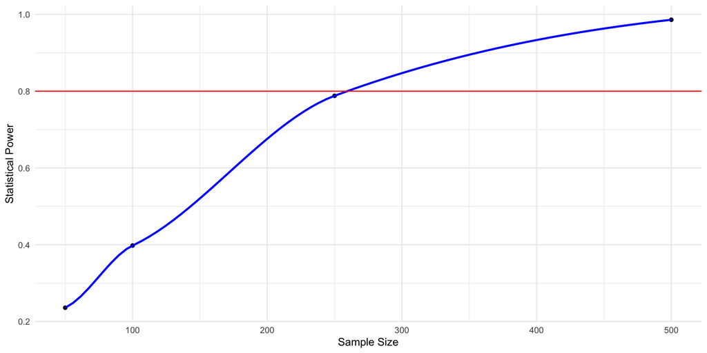

```r
ggplot(two_arm_power, aes(sample_size, estimate)) +
  geom_point() +
  geom_smooth(method = "loess", color = "blue") +
  geom_hline(yintercept = 0.8, color = "red") +
  labs(x = "Sample Size", y = "Statistical Power") +
  theme_minimal()
```

## Two-arm experiments with covariates

```r
set.seed(385)

model <-
  declare_model(
    N = 10000,
    X = rep(c(0, 1), each = N / 2),
    U = rnorm(N, sd = 0.25),
    potential_outcomes(Y ~ 0.2 * Z + X + U)
  )
inquiry <-
  declare_inquiry(ATE = mean(Y_Z_1 - Y_Z_0))
sampling <-
  declare_sampling(S = complete_rs(N = N, n = sample_size))
assignment <-
  declare_assignment(Z = complete_ra(N = N, m = sample_size/2))
measurement <-
  declare_measurement(Y = reveal_outcomes(Y ~ Z))
answer_strategy <-
  declare_estimator(Y ~ Z, .method = lm_robust, inquiry = "ATE", label = "OLS")

two_arms_a <-
  model +
  inquiry +
  sampling +
  assignment +
  measurement +
  answer_strategy

diagnosis_two_arms_a <- diagnose_design(two_arms_a)
diagnosis_two_arms_a
```

```
Research design diagnosis based on 500 simulations. Diagnosis completed in 2 secs. Diagnosand estimates with bootstrapped standard errors in parentheses (100 replicates).

     Design Inquiry Estimator Outcome Term N Sims Mean Estimand Mean Estimate
 two_arms_a     ATE       OLS       Y    Z    500          0.20          0.21
                                                         (0.00)        (0.01)
   Bias SD Estimate   RMSE  Power Coverage
   0.01        0.16   0.16   0.24     0.96
 (0.01)      (0.00) (0.00) (0.02)   (0.01)
```

## Two-arm experiments with covariates

```r
set.seed(385)

two_arm_cov <-
  model +
  inquiry +
  sampling +
  assignment +
  measurement +
  declare_estimator(Y ~ Z, covariates = ~ X, .method = lm_lin, inquiry = "ATE", label = "OLS with covariates")

diagnosis_two_arm_cov <- diagnose_design(two_arm_cov)
diagnosis_two_arm_cov
```

```
Research design diagnosis based on 500 simulations. Diagnosis completed in 2 secs. Diagnosand estimates with bootstrapped standard errors in parentheses (100 replicates).

      Design Inquiry           Estimator Outcome Term N Sims Mean Estimand
 two_arm_cov     ATE OLS with covariates       Y    Z    500          0.20
                                                                    (0.00)
 Mean Estimate   Bias SD Estimate   RMSE  Power Coverage
          0.20  -0.00        0.07   0.07   0.81     0.95
        (0.00) (0.00)      (0.00) (0.00) (0.02)   (0.01)
```

## Two-arm experiments without covariates

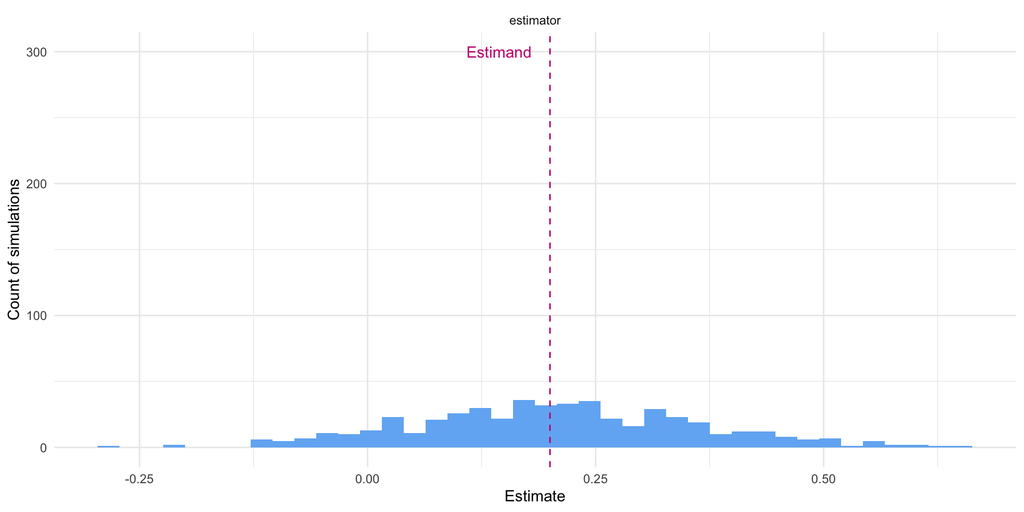

```r
simulations_ta <- get_simulations(diagnosis_two_arm)

# first create summary for vertical lines
summary_ta <-
  simulations_ta |>
  group_by(estimator) |>
  summarize(estimand = mean(estimand))

# then plot simulations
ggplot(simulations_ta) +
  geom_histogram(aes(estimate),
                 bins = 40, fill = "#72B4F3") +
  geom_vline(data = summary_ta,
             aes(xintercept = estimand),
             lty = "dashed", color = "#C6227F") +
  annotate("text", y = 300, x = 0.18, label = "Estimand",
           color = "#C6227F", hjust = 1) +
  facet_wrap(~ estimator) +
  labs(x = "Estimate", y = "Count of simulations") +
  theme_minimal()
```

## Two-arm experiments with covariates

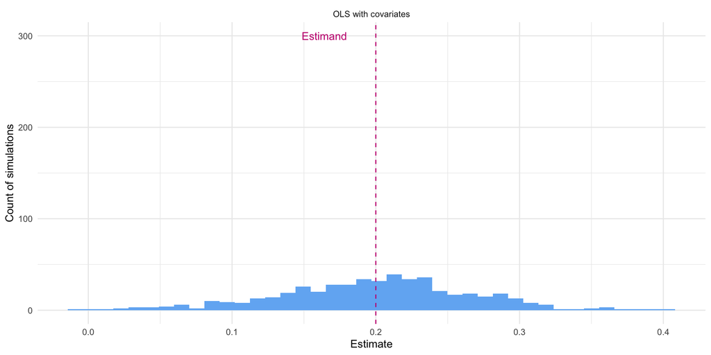

```r
simulations_tac <- get_simulations(diagnosis_two_arm_cov)

summary_tac <-
  simulations_tac |>
  group_by(estimator) |>
  summarize(estimand = mean(estimand))

# then plot simulations
ggplot(simulations_tac) +
  geom_histogram(aes(estimate),
                 bins = 40, fill = "#72B4F3") +
  geom_vline(data = summary_tac,
             aes(xintercept = estimand),
             lty = "dashed", color = "#C6227F") +
  annotate("text", y = 300, x = 0.18, label = "Estimand",
           color = "#C6227F", hjust = 1) +
  facet_wrap(~ estimator) +
  labs(x = "Estimate", y = "Count of simulations") +
  theme_minimal()
```

## Block randomisation two-arm experiment

```r
set.seed(385)

block_randomisation <-
  model +
  inquiry +
  declare_sampling(S = strata_rs(strata = X, n = 50)) +
  declare_assignment(Z = block_ra(blocks = X)) +
  measurement +
  declare_estimator(Y ~ Z, covariates = ~ X, .method = lm_lin, inquiry = "ATE", label = "Lin")

diagnosis_block_randomisation <- diagnose_design(block_randomisation)
diagnosis_block_randomisation
```

```
Research design diagnosis based on 500 simulations. Diagnosis completed in 4 secs. Diagnosand estimates with bootstrapped standard errors in parentheses (100 replicates).

              Design Inquiry Estimator Outcome Term N Sims Mean Estimand
 block_randomisation     ATE       Lin       Y    Z    500          0.20
                                                                  (0.00)
 Mean Estimate   Bias SD Estimate   RMSE  Power Coverage
          0.20   0.00        0.05   0.05   0.97     0.94
        (0.00) (0.00)      (0.00) (0.00) (0.01)   (0.01)
```

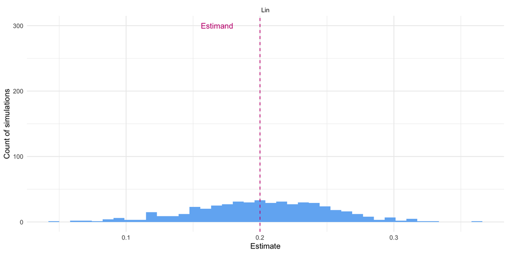

```r
simulations_br <- get_simulations(diagnosis_block_randomisation)

summary_br <-
  simulations_br |>
  group_by(estimator) |>
  summarize(estimand = mean(estimand))

# then plot simulations
ggplot(simulations_br) +
  geom_histogram(aes(estimate),
                 bins = 40, fill = "#72B4F3") +
  geom_vline(data = summary_br,
             aes(xintercept = estimand),
             lty = "dashed", color = "#C6227F") +
  annotate("text", y = 300, x = 0.18, label = "Estimand",
           color = "#C6227F", hjust = 1) +
  facet_wrap(~ estimator) +
  labs(x = "Estimate", y = "Count of simulations") +
  theme_minimal()
```

## Blocked and clustered randomisation

```r
set.seed(385)

ICC <- 0.9

block_cluster <-
  declare_model(
    cluster =
      add_level(
        N = 10,
        cluster_size = rep(seq(10, 50, 10), 2),
        cluster_shock =
          scale(cluster_size + rnorm(N, sd = 5)) * sqrt(ICC),
        cluster_tau = rnorm(N, sd = sqrt(ICC))
      ),
    individual =
      add_level(
        N = cluster_size,
        individual_shock = rnorm(N, sd = sqrt(1 - ICC)),
        individual_tau = rnorm(N, sd = sqrt(1 - ICC)),
        Y_Z_0 = cluster_shock + individual_shock,
        Y_Z_1 = Y_Z_0 + cluster_tau + individual_tau
      )
  ) +
  declare_inquiry(ATE = mean(Y_Z_1 - Y_Z_0)) +
  declare_assignment(Z = block_and_cluster_ra(clusters = cluster, blocks = cluster_size)) +
  declare_measurement(Y = reveal_outcomes(Y ~ Z)) +
  declare_estimator(Y ~ Z,
                    clusters = cluster,
                    inquiry = "ATE")

diagnosis_block_cluster <- diagnose_design(block_cluster)
diagnosis_block_cluster
```

```
Research design diagnosis based on 500 simulations. Diagnosis completed in 2 secs. Diagnosand estimates with bootstrapped standard errors in parentheses (100 replicates).

        Design Inquiry Estimator Outcome Term N Sims Mean Estimand
 block_cluster     ATE estimator       Y    Z    500          0.01
                                                            (0.01)
 Mean Estimate   Bias SD Estimate   RMSE  Power Coverage
         -0.02  -0.03        0.52   0.41   0.00     1.00
        (0.02) (0.02)      (0.01) (0.01) (0.00)   (0.00)
```

## Redesigning over values of ICC

```r
set.seed(385)

block_cluster_icc <-
  block_cluster |>
  redesign(ICC = seq(0.1, 0.9, by = 0.4)) |>
  diagnose_designs() |>
  tidy()

block_cluster_icc |>
  select(design, ICC, diagnosand, estimate) |>
  filter(diagnosand %in% c("mean_estimate", "sd_estimate"))
```

```
    design ICC    diagnosand    estimate
1 design_1 0.1 mean_estimate  0.00151772
2 design_1 0.1   sd_estimate  0.22702412
3 design_2 0.5 mean_estimate -0.01250764
4 design_2 0.5   sd_estimate  0.41689454
5 design_3 0.9 mean_estimate  0.04037843
6 design_3 0.9   sd_estimate  0.53993123
```

# DesignLibrary 📚

## DesignLibrary

### Making your life easier!

- [DesignLibrary](https://declaredesign.org/r/designlibrary/) is a companion package to DeclareDesign and it includes several common designs
- You can use these designs as templates for your own experiments!
- Let’s see how to create a simple [two-arm experiment with DesignLibrary](https://declaredesign.org/r/designlibrary/reference/two_arm_designer.html)

```r
library(DesignLibrary)

# two_arm_designer(
  # N = 100,
  # assignment_prob = 0.5,
  # control_mean = 0,
  # control_sd = 1,
  # ate = 1,
  # treatment_mean = control_mean + ate,
  # treatment_sd = control_sd,
  # rho = 1,
  # args_to_fix = NULL
# )

two_arm_design <- two_arm_designer(ate = 2, N = 1000)

two_arm_design
```

```
Research design declaration summary

Step 1 (population): declare_population(N = N, u_0 = rnorm(N), u_1 = rnorm(n = N, mean = rho * u_0, sd = sqrt(1 - rho^2)))

Step 2 (potential outcomes): declare_potential_outcomes(Y ~ (1 - Z) * (u_0 * control_sd + control_mean) + Z * (u_1 * treatment_sd + treatment_mean))

Step 3 (inquiry): declare_inquiry(ATE = mean(Y_Z_1 - Y_Z_0)) -------------------

Step 4 (assignment): declare_assignment(Z = complete_ra(N, prob = assignment_prob))

Step 5 (reveal): declare_reveal() ----------------------------------------------

Step 6 (estimator): declare_estimator(Y ~ Z, inquiry = estimand) ---------------

Run of the design:

 inquiry estimand estimator term estimate std.error statistic   p.value
     ATE        2 estimator    Z     1.94    0.0654      29.7 3.38e-139
 conf.low conf.high  df outcome
     1.81      2.07 998       Y

Parameters or objects saved in design environments:

N, rho, control_mean, control_sd, treatment_mean, treatment_sd, assignment_prob, estimand
```

## DesignLibrary

### Clustered designs

- You can create complex designs easily too!

```r
# A design with varying block size and varying cluster size
cluster_sampling_design <- cluster_sampling_designer(
  N_blocks = 2,
  N_clusters_in_block = 100,
  N_i_in_cluster = 50,
  n_clusters_in_block = 10,
  n_i_in_cluster = 10,
  icc = 0.1)

cluster_sampling_design
```

```
Research design declaration summary

Step 1 (population): declare_population(data = fixed_pop) ----------------------

Step 2 (inquiry): declare_inquiry(mean(Y), label = "Ybar") ---------------------

Step 3 (sampling): declare_sampling(S1 = strata_and_cluster_rs(strata = block, clusters = cluster, n = n_clusters_in_block), filter = S1 == 1)

Step 4 (sampling): declare_sampling(S2 = strata_rs(strata = cluster, n = n_i_in_cluster), filter = S2 == 1)

Step 5 (estimator): declare_estimator(Y ~ 1, model = lm_robust, clusters = cluster, inquiry = estimand, label = "Clustered Standard Errors")

Run of the design:

 inquiry estimand                 estimator        term estimate std.error
    Ybar     3.98 Clustered Standard Errors (Intercept)     3.82     0.168
 statistic  p.value conf.low conf.high df outcome
      22.8 3.01e-15     3.47      4.18 19       Y

Parameters or objects saved in design environments:

                name    value_str steps
            estimand     function     5
           fixed_pop <data.frame>     1
 n_clusters_in_block           10     3
      n_i_in_cluster           10     4
```

# DesignWizard 🧙

## DesignWizard

- Our friends at DeclareDesign have created a tool called [DesignWizard](https://eos.wzb.eu/ipi/DDWizard/) that can help you create and diagnose designs interactively
- It’s a great way to get started with DeclareDesign without writing any code!
- DesignWizard asks a few questions about your research goals and then generates the corresponding DeclareDesign code for you
- It even generates the simulations and diagnoses for you automatically!
- Give it a try! 🧙

[figure not shown]

https://eos.wzb.eu/ipi/DDWizard/

# Summary 📚

## Today we learned…

- The basics of [Quarto](https://quarto.org/) and [DeclareDesign](https://declaredesign.org/)
- How to write a Quarto document that includes text, code, and visualisations
- The importance of literate programming for reproducible research
- How to use DeclareDesign to plan and execute experiments
- The six components of a DeclareDesign study
- How to use DesignLibrary to create common designs

## Further readings

- You can find more information about Quarto at https://quarto.org/
- Many templates are available in the Quarto Gallery: https://quarto.org/gallery/
- I have a personal collection of PDF templates available at https://github.com/danilofreire/quarto-templates
- Familiarise yourself with `fabricatr` at https://declaredesign.org/r/fabricatr/
- If you want to dive deeper into the MIDA framework, please read chapters 5–13 here: https://book.declaredesign.org/declaration-diagnosis-redesign/declaring-designs.html
- And if you want to learn more about the DesignLibrary, please visit https://declaredesign.org/r/designlibrary/

## Quarto cheat sheet

[figure not shown]

Source: https://raw.githubusercontent.com/rstudio/cheatsheets/master/quarto.pdf

## DeclareDesign cheat sheet

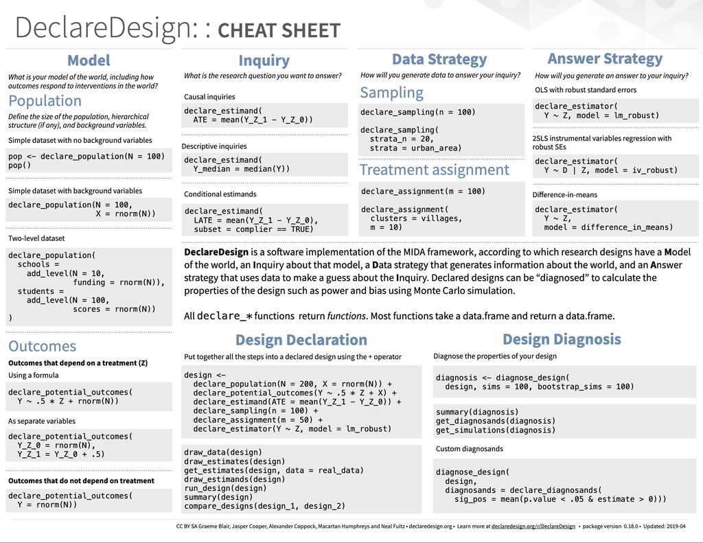

Source: https://raw.githubusercontent.com/rstudio/cheatsheets/master/declaredesign.pdf

# And that’s all for today! 🎉